# Lab 3: Gesture Recognition using Convolutional Neural Networks

### Part (b) Training Code - 5 pt

Write code that trains your neural network given some training data. Your training code should make it easy to tweak the usual hyperparameters, like batch size, learning rate, and the model object itself. Make sure that you are checkpointing your models from time to time (the frequency is up to you). Explain your choice of loss function and optimizer.

```python
def train (model,

           data_path=None,
           train_loader=None,
           val_loader=None,

           batch_size=64,
           learning_rate=0.01,
           num_epochs=10):

  # Consistent seed
  torch.manual_seed(1)
  np.random.seed(1)

  # Retrieve data loaders
  # Set loss function and gradient descent optimizer
  if data_path is None:
    train_loader = train_loader
    val_loader = val_loader
  else:
    train_loader, val_loader, test_loader = get_data_loader(data_path=data_path, batch_size=batch_size)

  criterion = nn.CrossEntropyLoss()
  optimizer = optim.Adam(model.parameters(), lr=learning_rate)

  #############################################
  #To Enable GPU Usage
  if use_cuda and torch.cuda.is_available():
    print('CUDA is available!  Training on GPU ...')
    criterion = criterion.cuda()
    model = model.cuda()
  #############################################

  epochs, losses, train_acc, val_acc = [], [], [], []

  # Training
  # Start timing
  start_time = time.time()
  for epoch in range(num_epochs):
    print("Epoch {}/{} ...".format(epoch + 1, num_epochs))

    for images, labels in train_loader:
      #############################################
      #To Enable GPU Usage
      if use_cuda and torch.cuda.is_available():
        images = images.cuda()
        labels = labels.cuda()
      #############################################

      out = model(images)
      loss = criterion(out, labels)
      loss.backward()
      optimizer.step()
      optimizer.zero_grad()

    epochs.append(epoch)
    losses.append(float(loss.item())/batch_size)
    train_acc.append(get_accuracy(model, train_loader))
    val_acc.append(get_accuracy(model, val_loader))

  # Plotting
  plt.title("Training Curve")
  plt.plot(epochs, losses, label="Train")
  plt.xlabel("Epochs")
  plt.ylabel("Loss")
  plt.show()

  plt.title("Training Curve")
  plt.plot(epochs, train_acc, label="Train")
  plt.plot(epochs, val_acc, label="Validation")
  plt.xlabel("Epochs")
  plt.ylabel("Training Accuracy")
  plt.legend(loc='best')
  plt.show()

  print("Final Training Accuracy: {}".format(train_acc[-1]))
  print("Final Validation Accuracy: {}".format(val_acc[-1]))

  end_time = time.time()
  elapsed_time = end_time - start_time
  print("Total time elapsed: {:.2f} seconds".format(elapsed_time))
```

### Part (c) “Overfit” to a Small Dataset - 5 pt

One way to sanity check our neural network model and training code is to check whether the model is capable of “overfitting” or “memorizing” a small dataset. A properly constructed CNN with correct training code should be able to memorize the answers to a small number of images quickly.

Construct a small dataset (e.g. just the images that you have collected). Then show that your model and training code is capable of memorizing the labels of this small data set.

With a large batch size (e.g. the entire small dataset) and learning rate that is not too high, You should be able to obtain a 100% training accuracy on that small dataset relatively quickly (within 200 iterations).

```
CUDA is available!  Training on GPU ...
```

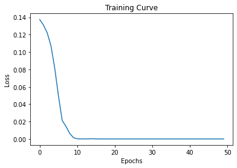

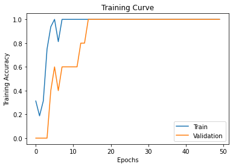

```
Final Training Accuracy: 1.0
Final Validation Accuracy: 1.0
Total time elapsed: 10.04 seconds
```

```python
SmallNet = ASLNet()

# Set batch size to 16 (the whole training set)
# Since it is a smaller dataset, train slower
# Set the number of epochs to 50 << 200
train(SmallNet,
      data_path='/content/gdrive/MyDrive/Colab Notebooks/Labs/lee-1004112177',
      batch_size=16,
      learning_rate=0.0025,
      num_epochs=50)
```

### 3. Hyperparameter Search [10 pt]

### Part (a) - 1 pt

List 3 hyperparameters that you think are most worth tuning. Choose at least one hyperparameter related to the model architecture.

```python
# In my opinion, the 3 most important hyperparameters that are worth tuning are
# batch size, learning rate, and size of convolutional layers. Batch size and
# learning rate are two simple learnable hyperparamters that can vastly affect
# the training quality and test accuracy. Convolutional layer sizes can control
# how deep the information that is extracted and filtered out from the input.
```

### Part (b) - 5 pt

Tune the hyperparameters you listed in Part (a), trying as many values as you need to until you feel satisfied that you are getting a good model. Plot the training curve of at least 4 different hyperparameter settings.

```
Training on increased batch size and learning rate ...
CUDA is available!  Training on GPU ...
```

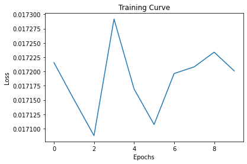

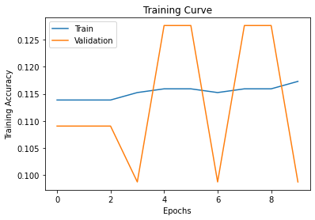

```
Final Training Accuracy: 0.11728395061728394
Final Validation Accuracy: 0.09876543209876543
Total time elapsed: 175.35 seconds
```

```python
RealNet = ASLNet()

print("Training on increased batch size and learning rate ...")
# Increase batch size
# Increase learning rate
train(RealNet,
      data_path='/content/gdrive/MyDrive/Colab Notebooks/Labs/Lab_3b_Gesture_Dataset',
      batch_size=128,
      learning_rate=0.02)
```

```
Training on decreased batch size and learning rate ...
CUDA is available!  Training on GPU ...
```

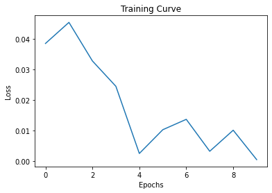

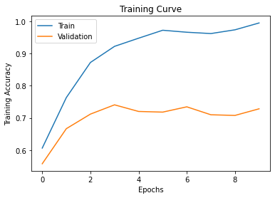

```
Final Training Accuracy: 0.99519890260631
Final Validation Accuracy: 0.7283950617283951
Total time elapsed: 130.81 seconds
```

```python
RealNet = ASLNet()

print("Training on decreased batch size and learning rate ...")
# Decrease batch size
# Decrease learning rate
train(RealNet,
      data_path='/content/gdrive/MyDrive/Colab Notebooks/Labs/Lab_3b_Gesture_Dataset',
      batch_size=32,
      learning_rate=0.005)
```

```
Training on increased kernel size ...
CUDA is available!  Training on GPU ...
```

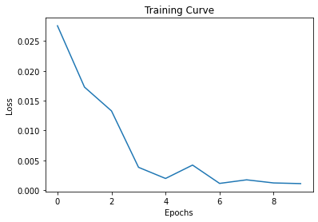

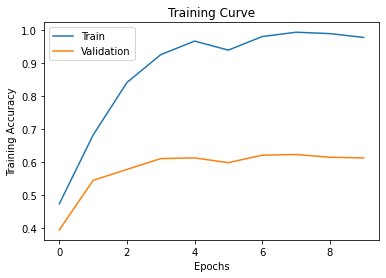

```
Final Training Accuracy: 0.9780521262002744
Final Validation Accuracy: 0.6131687242798354
Total time elapsed: 135.09 seconds
```

```python
print("Training on increased kernel size ...")
RealNet = ASLNet(kernel=7,
                 input_size=(10 * 51 * 51))
# Increase kernel size
train(RealNet,
      data_path='/content/gdrive/MyDrive/Colab Notebooks/Labs/Lab_3b_Gesture_Dataset')
```

```
Training on decreased kernel size ...
CUDA is available!  Training on GPU ...
```

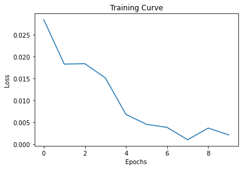

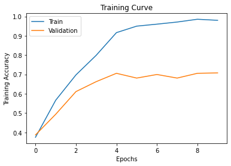

```
Final Training Accuracy: 0.9801097393689986
Final Validation Accuracy: 0.7078189300411523
Total time elapsed: 133.75 seconds
```

```python
print("Training on decreased kernel size ...")
RealNet = ASLNet(kernel=3,
                 input_size=(10 * 54 * 54))
# Decrease kernel size
train(RealNet,
      data_path='/content/gdrive/MyDrive/Colab Notebooks/Labs/Lab_3b_Gesture_Dataset')
```